# Multiple Linear Regression

575 C1 Team 3

2020/10/26

Team Members Dingjie Chen, Siwen He, Hanzi Yu, Jiaqi Yin, Runsheng Wang

In this deliverable, we are performing Multiple Linear Regression on the facebook dataset. We first load the packages needed to perform the analysis and read in the delimited file. We modified the column names of the CSV file so that column names would not contain space, as space is not a valid name character in ggplot. We used the complete.cases() function to handle NA values. Also note that “Category” and “Paid” variables are being interpreted as a double by the col_guess() function. To use these two variables as categorical, we could call the as.factor() function.

```r
# loading packages
suppressPackageStartupMessages(library(tidyverse))
suppressPackageStartupMessages(library(modelr))
suppressPackageStartupMessages(library(hrbrthemes))
suppressPackageStartupMessages(library(GGally))
suppressPackageStartupMessages(library(gridExtra))
suppressPackageStartupMessages(library(plotly))

# loading datasets
fb <- read_delim("dataset_Facebook.csv", delim = ";")
fb <- fb[complete.cases(fb), ]

# center titles for ggplot
theme_update(plot.title = element_text(hjust = 0.5))
```

## Identifying Potential Covariates

Using T_Interactions as the response variable, we construct heatmaps for our potential covariates to identify meaningful relationships.

Intuitively, we picked the following covariates to construct heatmaps: T_Reach, T_Impression, Engaged_Users, Consumers, Consumption, Category, Paid

Since T_Interactions includes like, comment, and shares, some metrics such as “LP_Engage_With_Post” does not provide useful predictions for our response variable because they are composed of element from T_Interactions. Other variables such as “Comment” is simply a component of T_Interactions. Thus, we don’t consider these either. In other words, these variables are simply a function of T_Interactions.

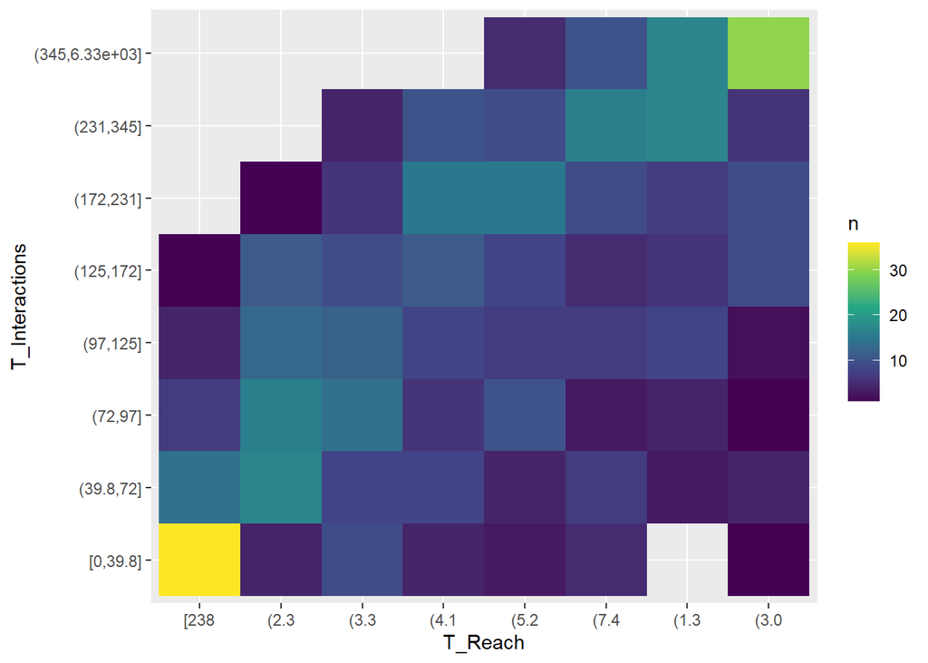

```r
# T_Reach heatmap
fb %>% transmute(T_Reach = cut_number(T_Reach, 8), T_Interactions = cut_number(T_Interactions, 8)) %>% count(T_Reach, T_Interactions) %>% ggplot(aes(T_Reach, T_Interactions)) + geom_tile(aes(fill = n)) + scale_x_discrete(labels = abbreviate) + scale_fill_viridis_c()
```

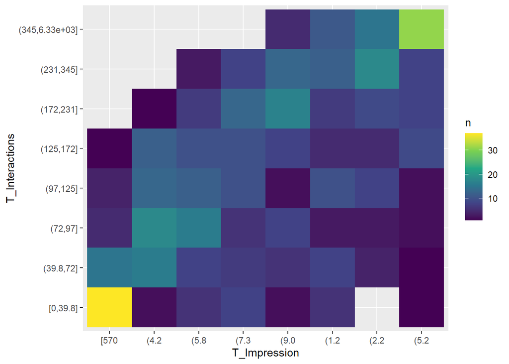

```r
# T_Impression heatmap
fb %>% transmute(T_Impression = cut_number(T_Impression, 8), T_Interactions = cut_number(T_Interactions, 8)) %>% count(T_Impression, T_Interactions) %>% ggplot(aes(T_Impression, T_Interactions)) + geom_tile(aes(fill = n)) + scale_x_discrete(labels = abbreviate) + scale_fill_viridis_c()
```

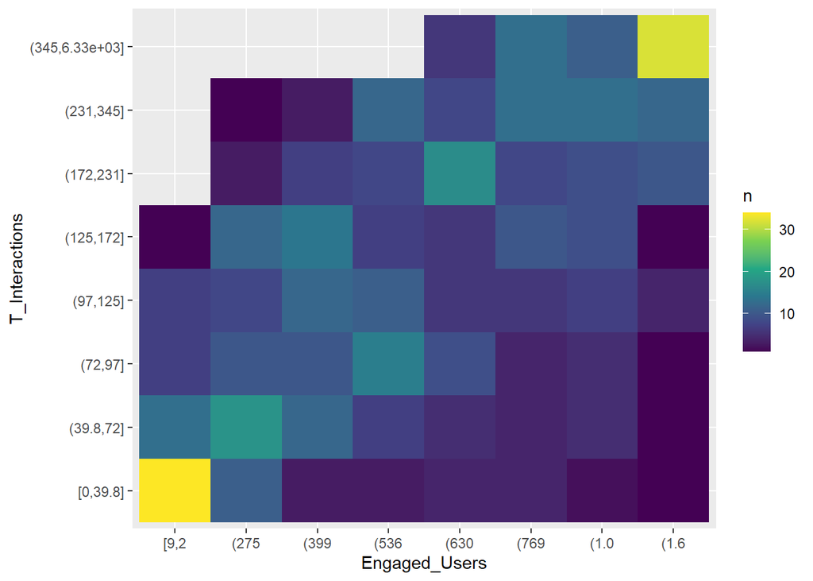

```r
# Engaged_Users heatmap
fb %>% transmute(Engaged_Users = cut_number(Engaged_Users, 8), T_Interactions = cut_number(T_Interactions, 8)) %>% count(Engaged_Users, T_Interactions) %>% ggplot(aes(Engaged_Users, T_Interactions)) + geom_tile(aes(fill = n)) + scale_x_discrete(labels = abbreviate) + scale_fill_viridis_c()
```

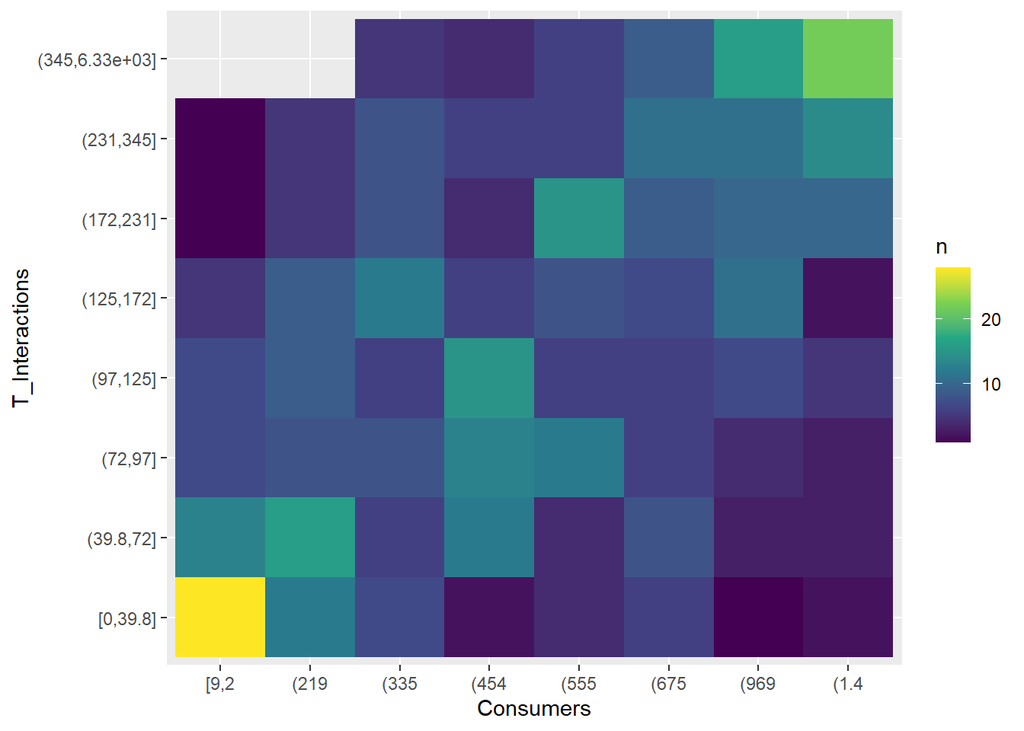

```r
# Consumers heatmap
fb %>% transmute(Consumers = cut_number(Consumers, 8), T_Interactions = cut_number(T_Interactions, 8)) %>% count(Consumers, T_Interactions) %>% ggplot(aes(Consumers, T_Interactions)) + geom_tile(aes(fill = n)) + scale_x_discrete(labels = abbreviate) + scale_fill_viridis_c()
```

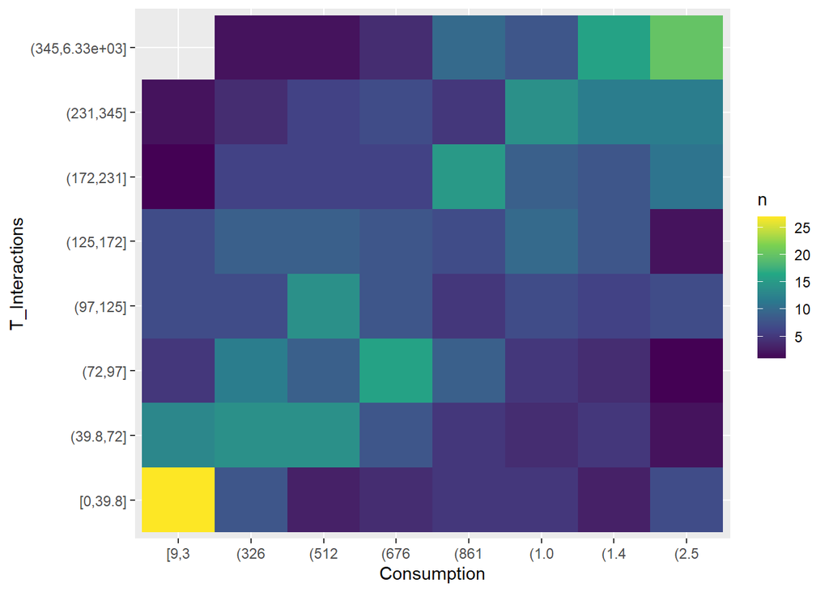

```r
# Consumption heatmap
fb %>% transmute(Consumption = cut_number(Consumption, 8), T_Interactions = cut_number(T_Interactions, 8)) %>% count(Consumption, T_Interactions) %>% ggplot(aes(Consumption, T_Interactions)) + geom_tile(aes(fill = n)) + scale_x_discrete(labels = abbreviate) + scale_fill_viridis_c()
```

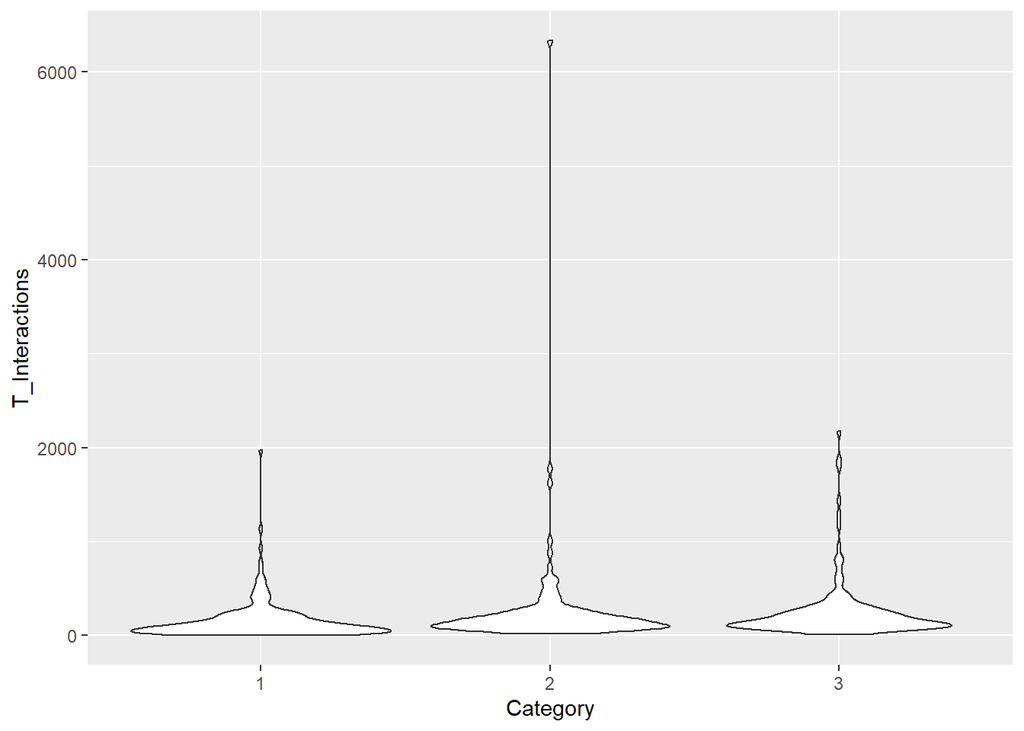

```r
# Category plot
fb %>% ggplot(aes(as.factor(Category), T_Interactions)) + geom_violin() + scale_x_discrete(labels = abbreviate) + xlab("Category")
```

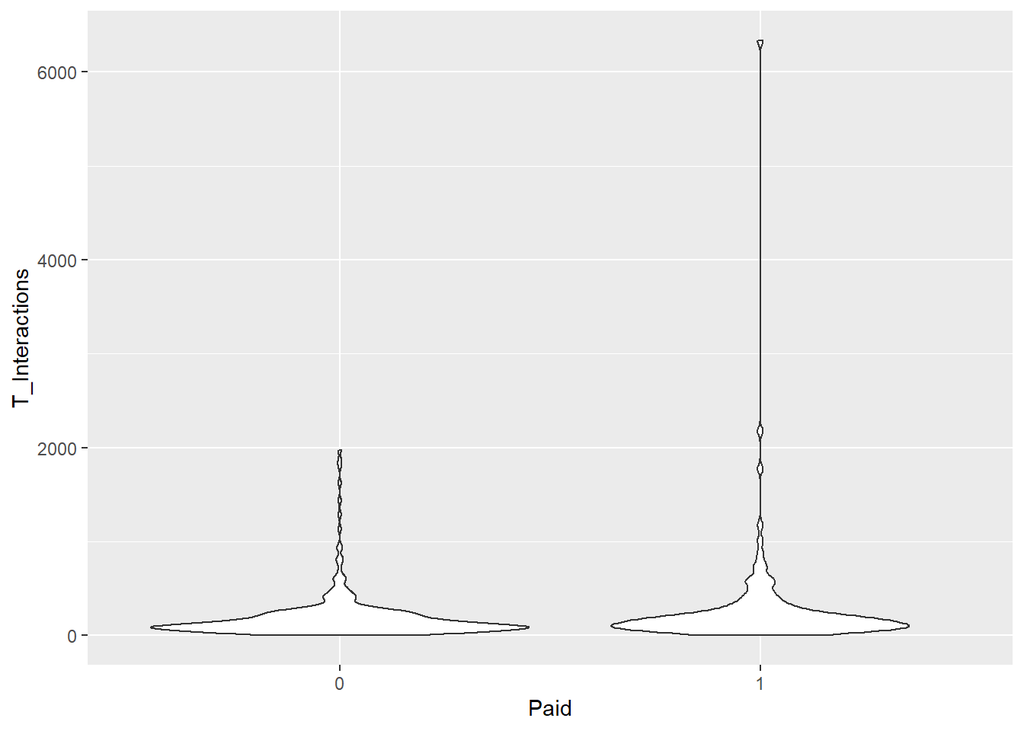

```r
# Paid plot
fb %>% ggplot(aes(as.factor(Paid), T_Interactions)) + geom_violin() + scale_x_discrete(labels = abbreviate) + xlab("Paid")
```

## Removing Outliers

Before proceeding with our analysis, we need to first remove outliers from our data

```r
# computer mean and sd
reach_mean = mean(fb$T_Reach)
reach_sd = sd(fb$T_Reach)
impress_mean = mean(fb$T_Impression)
impress_sd = sd(fb$T_Impression)
cons_mean = mean(fb$Consumption)
cons_sd = sd(fb$Consumption)
eu_mean = mean(fb$Engaged_Users)
eu_sd = sd(fb$Engaged_Users)

# compute table without outliers beyond 3 standard deviation
fb.clean <- fb %>% filter(T_Reach <= reach_mean+3*reach_sd, T_Impression <= impress_mean+3*impress_sd, Consumption <= cons_mean+3*cons_sd, Engaged_Users <= eu_mean+3*eu_sd)

# calculate percentage of datapoints considered
removedt <- (1 - nrow(fb.clean)/nrow(fb))*100
percentage_tibble <- tribble(~Variable, ~Percentage_Removed, "Overall", removedt)
(percentage_tibble)
```

| Variable | Percentage_Removed |
| --- | --- |
| Overall | 5.454545 |

By including datapoints within 3 standard deviation from the mean for all four variables, we removed 5.45% of the total data points.

Now, we proceed to calculate MLS

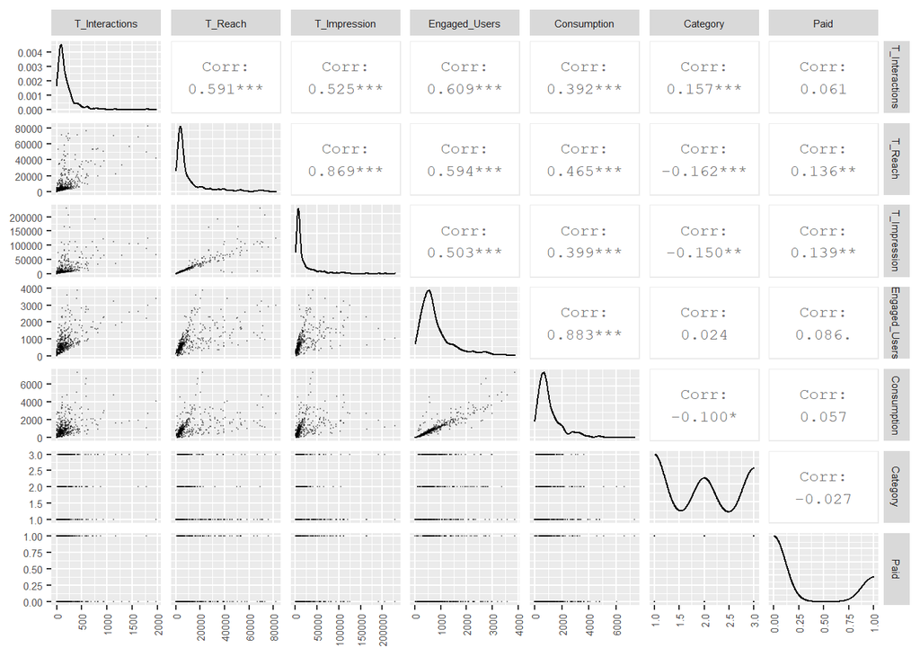

```r
# scatter matrix
fb.clean %>% select(T_Interactions, T_Reach, T_Impression, Engaged_Users, Consumption, Category, Paid) %>% ggpairs(lower = list(continuous = wrap("points", alpha = 0.3, size=0.1)), upper = list(continuous = wrap("cor", size = 3))) + theme(axis.text.x = element_text(angle = 90, vjust = 0.5, hjust=1), strip.placement = "outside", text = element_text(size = 7))
```

From the scatter matrix, we noticed that there are two pairs of variable who have a very high correlation between them. Namely, T_Reach and T_Impression has a correlation factor of 0.869; Engaged_Users and Consumption has a correlation factor of 0.883. These can also be seen from the linear trend that’s present in the scatter plots for these two pairs of variable. Based on the scatter matrix, we decided to remove one variable from each pair of strongly correlated variable. We choose to remove the one that has a lower correlation to our response variable T_Interactions. Since T_Reach and Engaged_Users have a higher correlation to T_Impression in each respective pairs, we remove T_Impression and Consumption from the MLR. Notice that Paid is a categorical variable that could affect the intercept. However, it’s correlation is extremely low. Thus, we remove Paid as well. We choose to keep Category because it has a significant correlation with T_Interactions (from the *** next to the correlation coefficient). Our model would be better after removing these variable because they do not provide much extra information, and we would suffer from losing degrees of freedom as well as a potential for lower R-Square values.

## Performing MLS

```r
m.mls <- lm(T_Interactions ~ T_Reach + Engaged_Users + as.factor(Category), data = fb.clean)
summary(m.mls)
```

```
##
## Call:
## lm(formula = T_Interactions ~ T_Reach + Engaged_Users + as.factor(Category),
##     data = fb.clean)
##
## Residuals:
##     Min      1Q  Median      3Q     Max
## -683.95  -73.43   -1.08   51.57 1305.52
##
## Coefficients:
##                        Estimate Std. Error t value Pr(>|t|)
## (Intercept)          -5.004e+01  1.559e+01  -3.210  0.00142 **
## T_Reach               6.939e-03  7.023e-04   9.879  < 2e-16 ***
## Engaged_Users         1.268e-01  1.562e-02   8.116 4.38e-15 ***
## as.factor(Category)2  8.704e+01  2.077e+01   4.190 3.34e-05 ***
## as.factor(Category)3  1.202e+02  1.890e+01   6.362 4.78e-10 ***
## ---
## Signif. codes:  0 '***' 0.001 '**' 0.01 '*' 0.05 '.' 0.1 ' ' 1
##
## Residual standard error: 170.3 on 463 degrees of freedom
## Multiple R-squared:  0.4984, Adjusted R-squared:  0.494
## F-statistic:   115 on 4 and 463 DF,  p-value: < 2.2e-16
```

```r
coef(m.mls)
```

```
##          (Intercept)              T_Reach        Engaged_Users
##        -50.044717045          0.006938575          0.126770682
## as.factor(Category)2 as.factor(Category)3
##         87.035268104        120.223631544
```

Both T_Reach and Engaged_Users have high t-values (9.879 and 8.116 respectively), allowing us to reject the null at 99.99% confidence level. Their p values are order of more than one magnitude smaller than 1, we could even reject at 99.9999%. The standard errors and estimates for these two variables differ by an order of one magnitude, which indicates we have small errors on these variables relative to their actual values.

We are also very confident with the other two categorical predictors. Notice that the null hypothesis for both of them is to test whether they differ from the intercept of category 1. It is not a test for whether the intercepts are zero or not. As we can see from the relative high t values (4.190 and 6.362) and the very low p values (3.34e-05 and 4.78e-10), we can safely say at 99.99% confidence that category differences do affect T_Interactions.

Based on the t values and p values, we can say that these predictors are definitely useful for inferring values of T_Interactions. However, we could still improve on our model to increase the R-Square value. The equation of the mls prediction is

T_Interactions = -50.044717045 + 0.006938575(T_Reach) + 0.126770682(Engaged_Users) + 87.035268104(Category2) + 120.223631544 (Category3)

## 3D Model

We created graphs to visualize the actual data against our predicted data.

```r
# this portion constructs the two 3D plots.
fb.clean <- fb.clean %>% add_predictions(m.mls)
fb.clean %>% plot_ly(x = ~T_Reach, y = ~Engaged_Users, z = ~T_Interactions, color = ~as.factor(Category), colors = c('Orange', 'Purple')) %>% add_markers(size = 5)
fb.clean %>% plot_ly(x = ~T_Reach, y = ~Engaged_Users, z = ~pred, color = ~as.factor(Category), colors = c('#BF382A', '#0C4B8E')) %>% add_markers(size = 5)
```

[output not shown]

## Interaction Terms

One way to improve our model from regular mls is to account for interaction terms.

From our scatter matrix previously, we see that T_Reach and Engaged_Users are somewhat correlated (with correlation coefficient 0.594). We attempt to take into account potential interactions between these two terms (since they might not be completely independent). We want to use SSR from the “Engaged_Users ~ T_Reach” model to predict the SSR of the mls model.

```r
m.mls <- lm(T_Interactions ~ T_Reach + Engaged_Users + as.factor(Category) + T_Reach:Engaged_Users, data = fb.clean)
summary(m.mls)
```

```
##
## Call:
## lm(formula = T_Interactions ~ T_Reach + Engaged_Users + as.factor(Category) +
##     T_Reach:Engaged_Users, data = fb.clean)
##
## Residuals:
##      Min       1Q   Median       3Q      Max
## -1040.18   -70.08   -18.14    40.04  1096.82
##
## Coefficients:
##                         Estimate Std. Error t value Pr(>|t|)
## (Intercept)            2.723e+01  1.724e+01   1.579   0.1149
## T_Reach               -3.144e-04  1.088e-03  -0.289   0.7728
## Engaged_Users          3.774e-02  1.806e-02   2.090   0.0372 *
## as.factor(Category)2   8.874e+01  1.938e+01   4.578 6.04e-06 ***
## as.factor(Category)3   1.165e+02  1.764e+01   6.605 1.09e-10 ***
## T_Reach:Engaged_Users  5.202e-06  6.230e-07   8.349 8.07e-16 ***
## ---
## Signif. codes:  0 '***' 0.001 '**' 0.01 '*' 0.05 '.' 0.1 ' ' 1
##
## Residual standard error: 158.9 on 462 degrees of freedom
## Multiple R-squared:  0.5641, Adjusted R-squared:  0.5594
## F-statistic: 119.6 on 5 and 462 DF,  p-value: < 2.2e-16
```

```r
coef(m.mls)
```

```
##           (Intercept)               T_Reach         Engaged_Users
##          2.723438e+01         -3.143857e-04          3.774444e-02
##  as.factor(Category)2  as.factor(Category)3 T_Reach:Engaged_Users
##          8.874017e+01          1.165077e+02          5.201554e-06
```

From this output, we see that we can no longer reject the null hypothesis for both the Intercept and T_Reach. In fact, the p value for T_Reach is extremely large in this model, and we lost confidence on Engaged_Users as well. We do have confidence in the interaction term as well as a higher R-Square value, but this model is not useful due to its lack of confidence for T_Reach and Engaged_Users as predictors.

## Residuals

Now we construct plots for residuals on mls

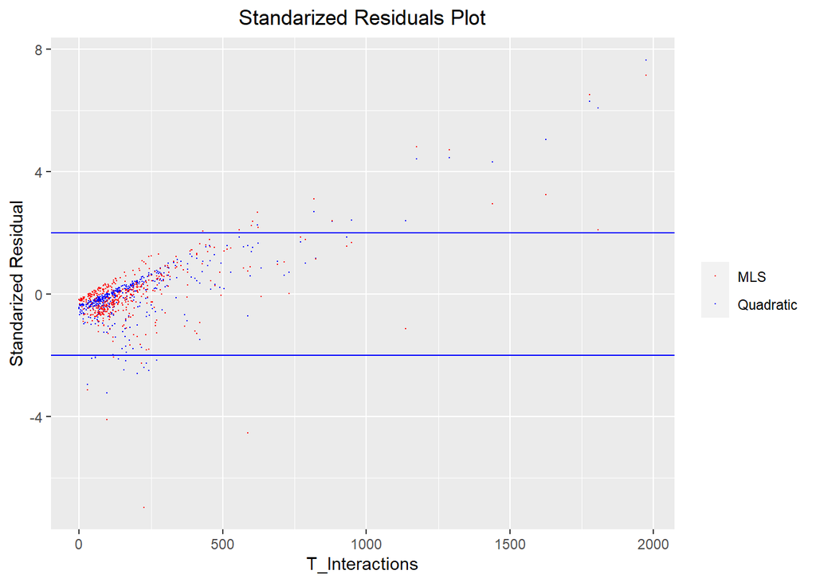

```r
# first build residual from quadratic model to compare against mls
m.qls <- fb.clean %>% lm(T_Interactions ~ T_Reach + I(T_Reach^2), .)
StanResQLS <- rstandard(m.qls)

# standardize for mls and plotting
StanResMLS <- rstandard(m.mls)
fb.clean %>% ggplot() + geom_point(aes(T_Interactions, StanResQLS, color = "Quadratic"), size = 0.1) +
geom_point(aes(T_Interactions, StanResMLS, color = "MLS"), size = 0.1) +
geom_hline(yintercept=2,color='blue') + geom_hline(yintercept=-2, color='blue') +
scale_color_manual(name = element_blank(), labels = c("MLS","Quadratic"), values = c("red","blue")) +
labs(y = "Standarized Residual") + ggtitle("Standarized Residuals Plot")
```

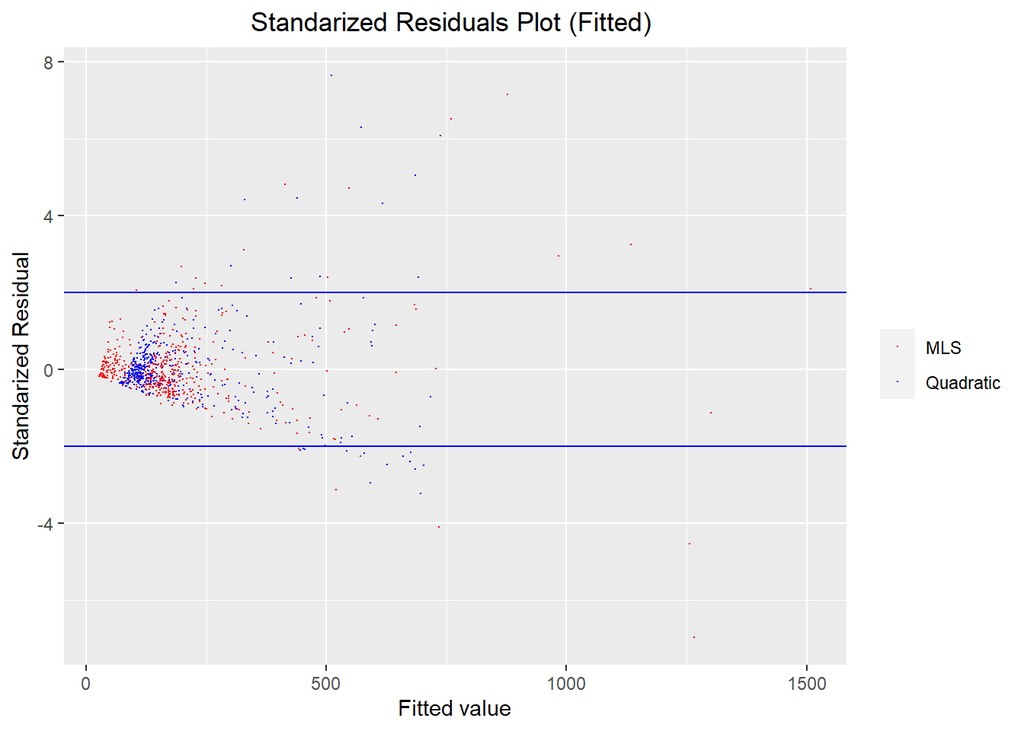

```r
# fitted residuals
qfit = fitted(m.qls)
mfit = fitted(m.mls)

fb.clean %>% ggplot() + geom_point(aes(qfit, StanResQLS, color = "Quadratic"), size = 0.1) + geom_point(aes(mfit, StanResMLS, color = "MLS"), size = 0.1) +
geom_hline(yintercept=2,color='blue') + geom_hline(yintercept=-2, color='blue') +
scale_color_manual(name = element_blank(), labels = c("MLS","Quadratic"), values = c("red","blue")) +
labs(y = "Standarized Residual") + labs(x = "Fitted value") +
ggtitle("Standarized Residuals Plot (Fitted) ")
```

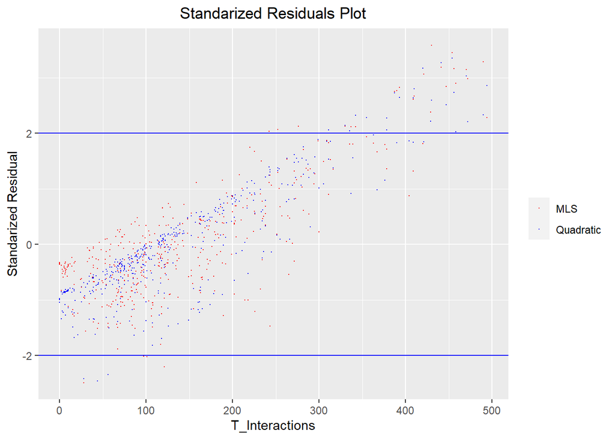

```r
# first build residual from quadratic model to compare against mls
m.qls1 <- fb.clean %>% filter(T_Interactions <= 500) %>% lm(T_Interactions ~ T_Reach + I(T_Reach^2), .)
StanResQLS1 <- rstandard(m.qls1)

# standardize for mls and plotting
m.mls1 <- fb.clean %>% filter(T_Interactions <= 500) %>% lm(T_Interactions ~ T_Reach + Engaged_Users + as.factor(Category) + T_Reach:Engaged_Users, .)
StanResMLS1 <- rstandard(m.mls1)
fb.clean %>% filter(T_Interactions <= 500) %>% ggplot() + geom_point(aes(T_Interactions, StanResQLS1, color = "Quadratic"), size = 0.1) + geom_point(aes(T_Interactions, StanResMLS1, color = "MLS"), size = 0.1) +
geom_hline(yintercept=2,color='blue') + geom_hline(yintercept=-2, color='blue') +
scale_color_manual(name = element_blank(), labels = c("MLS","Quadratic"), values = c("red","blue")) +
labs(y = "Standarized Residual") + ggtitle("Standarized Residuals Plot")
```

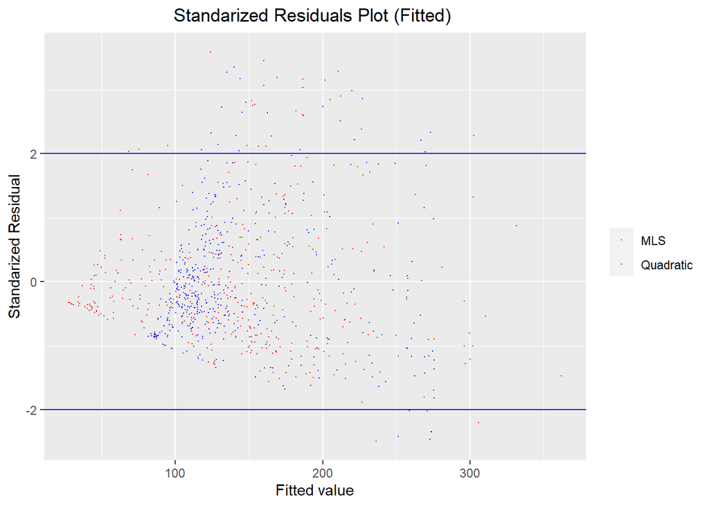

```r
# fitted residuals
qfit1 = fitted(m.qls1)
mfit1 = fitted(m.mls1)

fb.clean %>% filter(T_Interactions <= 500) %>% ggplot() + geom_point(aes(qfit1, StanResQLS1, color = "Quadratic"), size = 0.1) + geom_point(aes(mfit1, StanResMLS1, color = "MLS"), size = 0.1) +
geom_hline(yintercept=2,color='blue') + geom_hline(yintercept=-2, color='blue') +
scale_color_manual(name = element_blank(), labels = c("MLS","Quadratic"), values = c("red","blue")) +
labs(y = "Standarized Residual") + labs(x = "Fitted value") +
ggtitle("Standarized Residuals Plot (Fitted) ")
```